# import

# test

```python
pred0 = model0.predict(x_test_)
predGRU0 = modelGRU0.predict(x_test_)
pred21 = model21.predict(x_test_)
pred22 = model22.predict(x_test_)
pred31 = model31.predict(x_test_)
pred32 = model32.predict(x_test_)
```

# lstm model graph

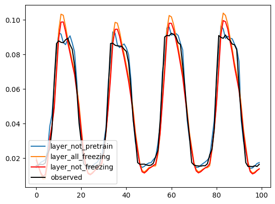

```python
n =100
plt.plot(pred0[:n],label = 'layer_not_pretrain')
plt.plot(pred21[:n],label = 'layer_all_freezing')
plt.plot(pred22[:n],label = 'layer_not_freezing',color = 'red')
#plt.plot(pred31[:n],label = 'last_not_freezing')
#plt.plot(pred32[:n],label = 'last_not_freezing',color='brown')
plt.plot(y_test.values.flatten()[:n],label = 'observed',color = 'black')
plt.legend(loc='lower left')
plt.show()
```

# GRU model graph

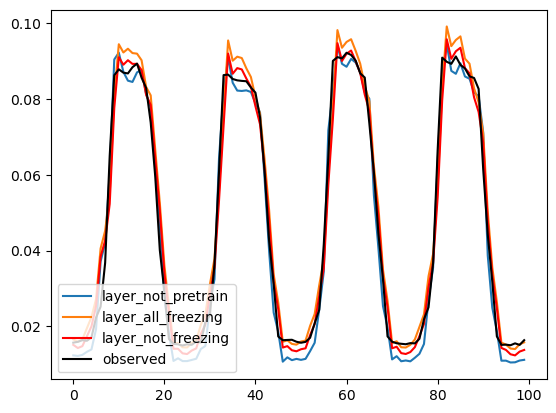

```python
n =100
plt.plot(predGRU0[:n],label = 'layer_not_pretrain')
plt.plot(pred31[:n],label = 'layer_all_freezing')
plt.plot(pred32[:n],label = 'layer_not_freezing',color = 'red')
plt.plot(y_test.values.flatten()[:n],label = 'observed',color = 'black')
plt.legend(loc='lower left')
plt.show()
```

# trained time, MSE table

```python
def MSE(y_pred, y_true):
    return np.mean((y_true - y_pred)**2)


def MAE(y_pred, y_true):
    absolute_errors = np.abs(y_true - y_pred)
    mae = np.mean(absolute_errors)
    return mae

def MAPE(y_true, y_pred):
    epsilon = 1e-10
    percentage_errors = np.abs((y_true - y_pred) / (y_true + epsilon)) * 100
    percentage_errors = np.nan_to_num(percentage_errors)
    mape = np.mean(percentage_errors)
    return mape
```

```python
y_true = y_test.values.flatten()

lst1 = [total_training_time0,total_training_time21,total_training_time22,
        total_training_time02,total_training_time31,total_training_time32]

lst2 =  [MSE(pred0.flatten(),y_test.values.flatten()), MSE(pred21.flatten(),y_test.values.flatten()),MSE(pred22.flatten(),y_test.values.flatten()),
        MSE(predGRU0.flatten(),y_test.values.flatten()),MSE(pred31.flatten(),y_test.values.flatten()),MSE(pred32.flatten(),y_test.values.flatten())]

lst3 = [MAE(pred0.flatten(),y_test.values.flatten()), MAE(pred21.flatten(),y_test.values.flatten()), MAE(pred22.flatten(),y_test.values.flatten()),
       MAE(predGRU0.flatten(),y_test.values.flatten()),MAE(pred31.flatten(),y_test.values.flatten()),MAE(pred32.flatten(),y_test.values.flatten())]

lst4 =  [MAPE(pred0.flatten(),y_test.values.flatten()), MAPE(pred21.flatten(),y_test.values.flatten()), MAPE(pred22.flatten(),y_test.values.flatten()),
        MAPE(predGRU0.flatten(),y_test.values.flatten()),MAPE(pred31.flatten(),y_test.values.flatten()),MAPE(pred32.flatten(),y_test.values.flatten())]

name = ['lstm_no_pretrain','lstm_use_freezing','lstm_not_freezing',
        'gru_no_pretrain','gru_use_freezing','gru_not_freezing']
```

```python
pd.options.display.float_format = '{:.7f}'.format
pd.DataFrame({'time(second)':lst1,
             'MSE':lst2,
              'MAE':lst3,
             'MAPE':lst4},index=name)
```

|  | time(second) | MSE | MAE | MAPE |
| --- | --- | --- | --- | --- |
| lstm_no_pretrain | 597.5092788 | 0.0000245 | 0.0033223 | 6.7637670 |
| lstm_use_freezing | 0.6313732 | 0.0000552 | 0.0057561 | 13.0592076 |
| lstm_not_freezing | 0.7993987 | 0.0000538 | 0.0056590 | 13.0443100 |
| gru_no_pretrain | 476.0165787 | 0.0000265 | 0.0037241 | 9.6591871 |
| gru_use_freezing | 0.8144565 | 0.0000284 | 0.0039708 | 8.2116652 |
| gru_not_freezing | 0.8647180 | 0.0000236 | 0.0032509 | 6.8255478 |

#### 학습 시행 1번 반복에 따른 결과입니다

`-`추가

- 전이학습 모델은 학습 속도가 매우빨라 patience 옵션을 조정해도 될것 같습니다.patience 옵션이 증가할수록 non_freezing model이 use_freezing model보다 성능이 좋은 것을 확인했습니다
- 모든 레이어를 freezing한 model은 학습 시행마다 결과 성능의 폭이 큰 차이로 벌어지는 것을 확인했습니다. 현재는 유의한 성능 차이가 보이지 않지만 다시 학습을 시행했을 경우에 유의한 성능차이가 나타날 수 있습니다.